# 05_area_perimeter_counting

## 05_area_perimeter_counting

#### Question

1. A polygon is drawn below. Find its perimeter and area. Assume the grid is composed of squares with each length equal to 1 centimeter. Thus, the area of each grid square is 1 $\mathrm{cm^2}$.

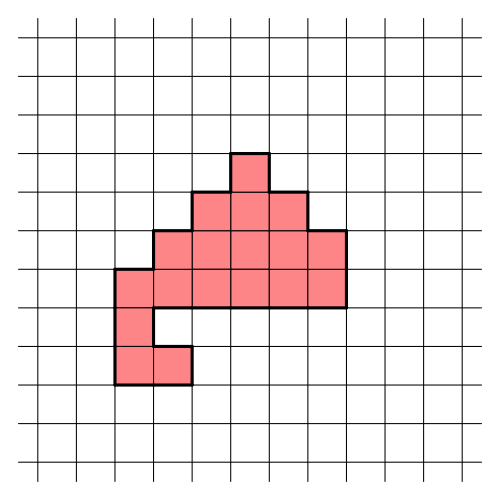

   - Perimeter =
   - Area =

#### Question

2. A polygon is drawn below. Find its perimeter and area. Assume the grid is composed of squares with each length equal to 1 centimeter. Thus, the area of each grid square is 1 $\mathrm{cm^2}$.

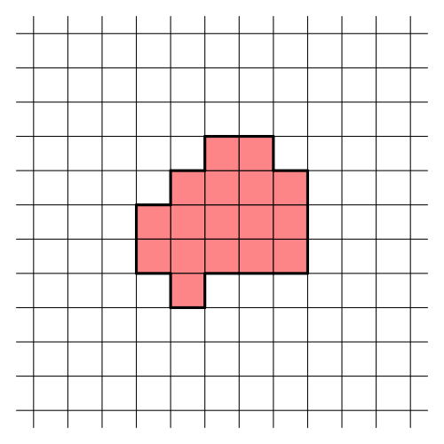

   - Perimeter =
   - Area =

#### Question

3. A polygon is drawn below. Find its perimeter and area. Assume the grid is composed of squares with each length equal to 1 centimeter. Thus, the area of each grid square is 1 $\mathrm{cm^2}$.

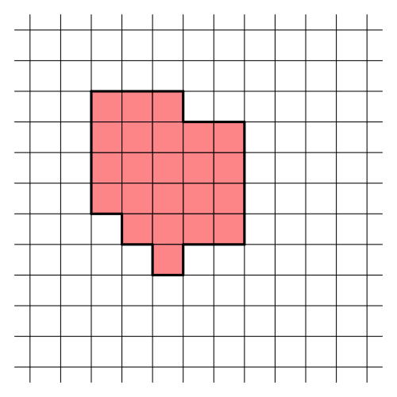

   - Perimeter =
   - Area =

#### Question

4. A polygon is drawn below. Find its perimeter and area. Assume the grid is composed of squares with each length equal to 1 centimeter. Thus, the area of each grid square is 1 $\mathrm{cm^2}$.

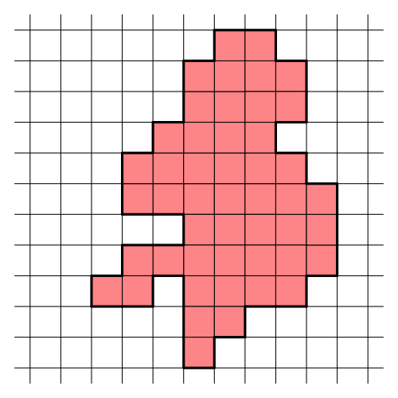

   - Perimeter =
   - Area =

#### Question

5. A polygon is drawn below. Find its perimeter and area. Assume the grid is composed of squares with each length equal to 1 centimeter. Thus, the area of each grid square is 1 $\mathrm{cm^2}$.

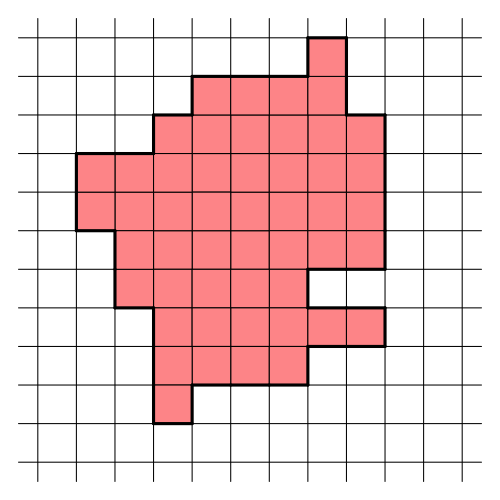

   - Perimeter =
   - Area =

#### Question

6. A polygon is drawn below. Find its perimeter and area. Assume the grid is composed of squares with each length equal to 1 centimeter. Thus, the area of each grid square is 1 $\mathrm{cm^2}$.

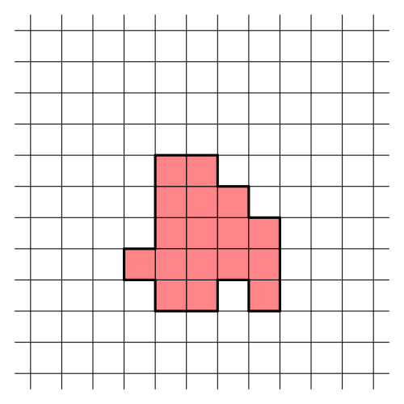

   - Perimeter =
   - Area =

#### Question

7. A polygon is drawn below. Find its perimeter and area. Assume the grid is composed of squares with each length equal to 1 centimeter. Thus, the area of each grid square is 1 $\mathrm{cm^2}$.

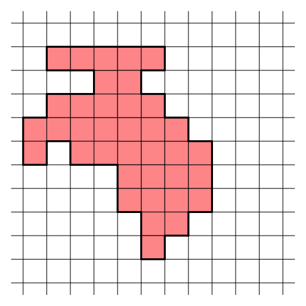

   - Perimeter =
   - Area =

#### Question

8. A polygon is drawn below. Find its perimeter and area. Assume the grid is composed of squares with each length equal to 1 centimeter. Thus, the area of each grid square is 1 $\mathrm{cm^2}$.

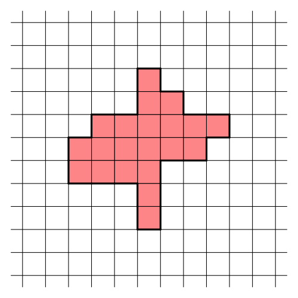

   - Perimeter =
   - Area =